# (Ford GoBike Dataset 2019)

## by (Ahmed Osama)

## Investigation Overview

> This data set includes information about individual rides made in a bike-sharing system covering the greater San Francisco Bay area. The goal is to assess and clean this data set to make it ready for the analysis, Then perform some Uni-variate, Bi-variate and Multi-variate analysis to get some useful and inspiring Insights!

## Dataset Overview

> This data set includes 183412 records about individual rides information made in a bike-sharing system covering the greater San Francisco Bay area in February 2019. It contains information like the start and end stations of the trip, start and end dates, Bike ID, Memebers birth date, Trips Duration and etc..

## Trip duration distribution variation between User Type and Member gender

> It seems that the gender doesn't affect so much on the duration compared to the User type. the genders are all close to each other. But for the types, the majority of the subscribers take a `1 to 10` trip duration. And the majority of the customer take a `8 to 20` trip duration.

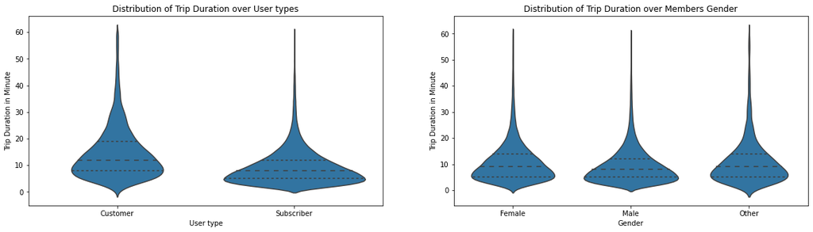

## Distribution of genders over the week days

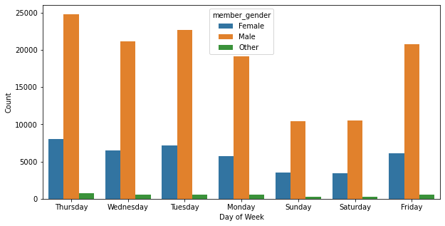

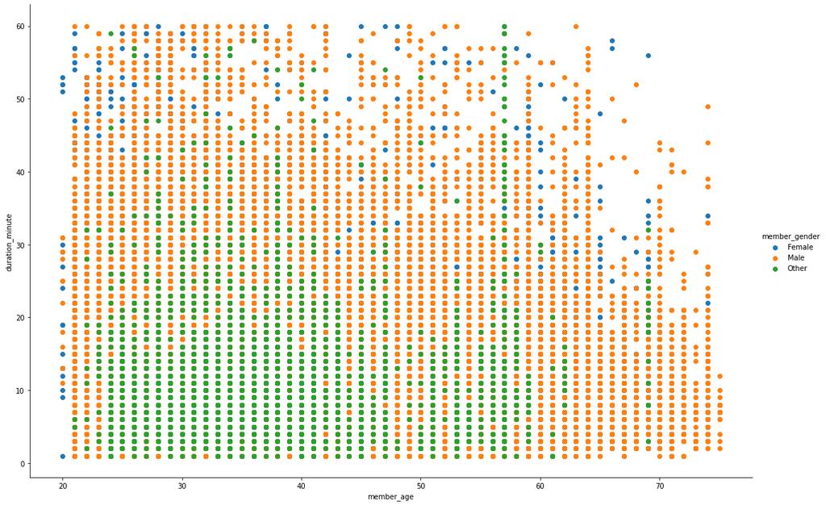

# Summary

> Univariate Exploration: For the Duration and times. The Most of trips have a rush hour range around `8-9am` and `17-18pm` during a day, there were more trips on work days `(Thursday - Tuesday)` working days compared to weekends. Most of trips were within `30 Minutes Duration` and the peaks within `5 to 15 Minutes`.

> Bivariate Exploration: The `gender` doesn't affect so much on the trip duration compared to the `User type`, Also the average trip durations are almost the same over the week days except for `Saturday and Sunday`, They have a higher average.

> The Multivariate Exploration: strengthened some of the patterns discovered in the previous bivariate exploration as well as univariate exploration and it discovered some new insights, the relationship between the multiple variables `Age - Duration - Gender` are plotted. Showing some new insights like the average age for the `Other` gender type and the average duration trip.